# R Notebook

```r
library(caret)
```

| store_id | price_ch | price_mm | disc_ch | disc_mm | special_ch | special_mm | loyal_ch | pct_disc_mm | pct_disc_ch | purchase_mm | quarterof_purchase |
| --- | --- | --- | --- | --- | --- | --- | --- | --- | --- | --- | --- |
| 1 | 1.75 | 1.99 | 0.00 | 0.00 | 0 | 0 | 0.500000 | 0.000000 | 0.000000 | FALSE | first |
| 1 | 1.75 | 1.99 | 0.00 | 0.30 | 0 | 1 | 0.600000 | 0.150754 | 0.000000 | FALSE | first |
| 1 | 1.86 | 2.09 | 0.17 | 0.00 | 0 | 0 | 0.680000 | 0.000000 | 0.091398 | FALSE | second |
| 1 | 1.69 | 1.69 | 0.00 | 0.00 | 0 | 0 | 0.400000 | 0.000000 | 0.000000 | TRUE | first |
| 7 | 1.69 | 1.69 | 0.00 | 0.00 | 0 | 0 | 0.956535 | 0.000000 | 0.000000 | FALSE | first |
| 7 | 1.69 | 1.99 | 0.00 | 0.00 | 0 | 1 | 0.965228 | 0.000000 | 0.000000 | FALSE | first |
| 7 | 1.69 | 1.99 | 0.00 | 0.40 | 1 | 1 | 0.972182 | 0.201005 | 0.000000 | FALSE | first |
| 7 | 1.75 | 1.99 | 0.00 | 0.40 | 1 | 0 | 0.977746 | 0.201005 | 0.000000 | FALSE | first |
| 7 | 1.75 | 1.99 | 0.00 | 0.40 | 0 | 0 | 0.982197 | 0.201005 | 0.000000 | FALSE | first |
| 7 | 1.75 | 1.99 | 0.00 | 0.40 | 0 | 0 | 0.985757 | 0.201005 | 0.000000 | FALSE | first |

[output cut: 990 more lines]

```r
alias(purchase_mm ~ ., data = juice)
```

```
Model :
purchase_mm ~ store_id + price_ch + price_mm + disc_ch + disc_mm +
    special_ch + special_mm + loyal_ch + pct_disc_mm + pct_disc_ch +
    quarterof_purchase
```

```r
glmulti_search_all_mains <- glmulti(
  purchase_mm ~ .,
  data = juice,
  level = 1,               # No interactions considered, main effects only
  method = "h",            # Exhaustive approach
  crit = "bic",            # BIC as criteria
  confsetsize = 10,        # Keep 10 best models
  plotty = F,
  report = T,              # No plots, but provide interim reports
  fitfunction = "glm",     # glm function
  family = binomial(link = "logit")) # binomial family for logistic regression

summary(glmulti_search_all_mains)
```

[output not shown]

```r
glmulti_search_previous_mains_one_pair <- glmulti(
  purchase_mm ~ price_ch + price_mm + disc_mm + loyal_ch + pct_disc_mm + pct_disc_ch,
  data = juice,
  level = 2,               # Interactions considered
  method = "h",            # Exhaustive approach
  crit = "bic",            # BIC as criteria
  confsetsize = 10,        # Keep 10 best models
  marginality = TRUE,      # consider pairs only if both main effects in model
  minsize = 7,             # minsize, maxsize and marginality here force
  maxsize = 7,             # inclusion of a single pair beyond the five main effects
  plotty = F,
  report = T,              # No plots, but provide interim reports
  fitfunction = "glm",     # glm function
  family = binomial(link = "logit")) # binomial family for logistic regression
```

```
Initialization...
TASK: Exhaustive screening of candidate set.
Fitting...

After 50 models:
Best model: purchase_mm~1+price_ch+price_mm+loyal_ch+pct_disc_mm+price_mm:price_ch+pct_disc_mm:price_ch+pct_disc_mm:price_mm
Crit= 908.369446727404
Mean crit= 909.039604257282

After 100 models:
Best model: purchase_mm~1+price_ch+price_mm+loyal_ch+pct_disc_mm+price_mm:price_ch+loyal_ch:price_mm+pct_disc_mm:price_mm
Crit= 908.090481291584
Mean crit= 908.748574519402

After 150 models:
Best model: purchase_mm~1+price_ch+price_mm+disc_mm+loyal_ch+pct_disc_mm+loyal_ch:disc_mm+pct_disc_mm:loyal_ch
Crit= 905.05772777241
Mean crit= 908.100175575511

After 200 models:
Best model: purchase_mm~1+price_ch+disc_mm+loyal_ch+pct_disc_ch+disc_mm:price_ch+pct_disc_ch:disc_mm+pct_disc_ch:loyal_ch
Crit= 899.872125450412
Mean crit= 904.251467964289

After 250 models:
Best model: purchase_mm~1+price_ch+price_mm+disc_mm+loyal_ch+pct_disc_ch+disc_mm:price_ch+loyal_ch:disc_mm
Crit= 887.739173942352
Mean crit= 888.509483488663

After 300 models:
Best model: purchase_mm~1+price_ch+price_mm+disc_mm+loyal_ch+pct_disc_ch+disc_mm:price_mm+pct_disc_ch:loyal_ch
Crit= 880.416685015313
Mean crit= 882.688191721263

After 350 models:
Best model: purchase_mm~1+price_ch+price_mm+disc_mm+loyal_ch+pct_disc_ch+disc_mm:price_mm+pct_disc_ch:loyal_ch
Crit= 880.416685015313
Mean crit= 882.688191721263

After 400 models:
```

[output cut: 9 more lines]

```
After 500 models:
Best model: purchase_mm~1+price_ch+price_mm+loyal_ch+pct_disc_mm+pct_disc_ch+pct_disc_mm:price_mm+pct_disc_ch:loyal_ch
Crit= 880.179063048541
Mean crit= 881.900370730536

After 550 models:
Best model: purchase_mm~1+price_ch+price_mm+loyal_ch+pct_disc_mm+pct_disc_ch+pct_disc_mm:price_mm+pct_disc_ch:loyal_ch
Crit= 880.179063048541
Mean crit= 881.900370730536

After 600 models:
Best model: purchase_mm~1+price_ch+price_mm+loyal_ch+pct_disc_mm+pct_disc_ch+pct_disc_mm:price_mm+pct_disc_ch:loyal_ch
Crit= 880.179063048541
Mean crit= 881.533273549303
Completed.
```

```r
summary(glmulti_search_previous_mains_one_pair)
```

```
$name
[1] "glmulti.analysis"

$method
[1] "h"

$fitting
[1] "glm"

$crit
[1] "bic"

$level
[1] 2

$marginality
[1] TRUE

$confsetsize
[1] 10

$bestic
[1] 880.1791

$icvalues
 [1] 880.1791 880.1791 880.4167 881.9222 881.9222 882.0206 882.0207 882.0582 882.0825 882.2268

$bestmodel
[1] "purchase_mm ~ 1 + price_ch + price_mm + loyal_ch + pct_disc_mm + "
[2] "    pct_disc_ch + pct_disc_mm:price_mm + pct_disc_ch:loyal_ch"

$modelweights
 [1] 0.17677118 0.17677112 0.15696850 0.07394217 0.07394123 0.07039083 0.07039070 0.06908254
 [9] 0.06824569 0.06349603

$includeobjects
[1] TRUE
```

Two of the interactions are better predictors than one of the main 6 variables. Let’s try with a maxsize = 6 to find only one interaction.

```r
glmulti_search_previous_mains_one_pair <- glmulti(
  purchase_mm ~ price_ch + price_mm + disc_mm + loyal_ch + pct_disc_mm + pct_disc_ch,
  data = juice,
  level = 2,               # Interactions considered
  method = "h",            # Exhaustive approach
  crit = "bic",            # BIC as criteria
  confsetsize = 10,        # Keep 10 best models
  marginality = TRUE,      # consider pairs only if both main effects in model
  minsize = 6,             # minsize, maxsize and marginality here force
  maxsize = 6,             # inclusion of a single pair beyond the five main effects
  plotty = F,
  report = T,              # No plots, but provide interim reports
  fitfunction = "glm",     # glm function
  family = binomial(link = "logit")) # binomial family for logistic regression
```

```
Initialization...
TASK: Exhaustive screening of candidate set.
Fitting...

After 50 models:
Best model: purchase_mm~1+price_ch+price_mm+loyal_ch+pct_disc_mm+price_mm:price_ch+pct_disc_mm:price_mm
Crit= 902.447697122354
Mean crit= 903.358766466102

After 100 models:
Best model: purchase_mm~1+price_ch+price_mm+loyal_ch+pct_disc_mm+price_mm:price_ch+pct_disc_mm:price_mm
Crit= 902.447697122354
Mean crit= 902.889592697873

After 150 models:
Best model: purchase_mm~1+price_ch+disc_mm+loyal_ch+pct_disc_ch+disc_mm:price_ch+pct_disc_ch:loyal_ch
Crit= 893.42468105083
Mean crit= 898.288319143921

After 200 models:
Best model: purchase_mm~1+price_ch+price_mm+disc_mm+loyal_ch+pct_disc_ch+disc_mm:price_mm
Crit= 875.996537733973
Mean crit= 882.500161346759

After 250 models:
Best model: purchase_mm~1+price_ch+price_mm+disc_mm+loyal_ch+pct_disc_ch+disc_mm:price_mm
Crit= 875.996537733973
Mean crit= 882.500161346759

After 300 models:
Best model: purchase_mm~1+price_ch+price_mm+loyal_ch+pct_disc_mm+pct_disc_ch+pct_disc_mm:price_mm
Crit= 875.792361328011
Mean crit= 881.216706288518
Completed.
```

```r
summary(glmulti_search_previous_mains_one_pair)
```

```
$name
[1] "glmulti.analysis"

$method
[1] "h"

$fitting
[1] "glm"

$crit
[1] "bic"

$level
[1] 2

$marginality
[1] TRUE

$confsetsize
[1] 10

$bestic
[1] 875.7923

$icvalues
 [1] 875.7923 875.7924 875.9965 880.9324 881.6430 881.6665 882.7329 882.7331 883.0121 883.3634

$bestmodel
[1] "purchase_mm ~ 1 + price_ch + price_mm + disc_mm + loyal_ch + "
[2] "    pct_disc_mm + pct_disc_ch"

$modelweights
 [1] 0.312685442 0.312682895 0.282336991 0.023930829 0.016774395 0.016579018 0.009727240 0.009726265
 [9] 0.008459801 0.007097124

$includeobjects
[1] TRUE
```

It keeps the original variables without interactions. Let’s calculate ROC curves and AUC to compare how good classifiers are the two models for the training data.

| store_id | price_ch | price_mm | disc_ch | disc_mm | special_ch | special_mm | loyal_ch | pct_disc_mm | pct_disc_ch | purchase_mm | quarterof_purchase | pred |
| --- | --- | --- | --- | --- | --- | --- | --- | --- | --- | --- | --- | --- |
| 1 | 1.75 | 1.99 | 0.00 | 0.00 | 0 | 0 | 0.500000 | 0.000000 | 0.000000 | FALSE | first | 0.390285129 |
| 1 | 1.75 | 1.99 | 0.00 | 0.30 | 0 | 1 | 0.600000 | 0.150754 | 0.000000 | FALSE | first | 0.319572996 |
| 1 | 1.86 | 2.09 | 0.17 | 0.00 | 0 | 0 | 0.680000 | 0.000000 | 0.091398 | FALSE | second | 0.084583782 |
| 1 | 1.69 | 1.69 | 0.00 | 0.00 | 0 | 0 | 0.400000 | 0.000000 | 0.000000 | TRUE | first | 0.775043963 |
| 7 | 1.69 | 1.69 | 0.00 | 0.00 | 0 | 0 | 0.956535 | 0.000000 | 0.000000 | FALSE | first | 0.087246788 |
| 7 | 1.69 | 1.99 | 0.00 | 0.00 | 0 | 1 | 0.965228 | 0.000000 | 0.000000 | FALSE | first | 0.025190498 |
| 7 | 1.69 | 1.99 | 0.00 | 0.40 | 1 | 1 | 0.972182 | 0.201005 | 0.000000 | FALSE | first | 0.037163577 |
| 7 | 1.75 | 1.99 | 0.00 | 0.40 | 1 | 0 | 0.977746 | 0.201005 | 0.000000 | FALSE | first | 0.044051407 |
| 7 | 1.75 | 1.99 | 0.00 | 0.40 | 0 | 0 | 0.982197 | 0.201005 | 0.000000 | FALSE | first | 0.042859761 |
| 7 | 1.75 | 1.99 | 0.00 | 0.40 | 0 | 0 | 0.985757 | 0.201005 | 0.000000 | FALSE | first | 0.041928883 |

[output cut: 990 more lines]

```r
roc_obj_interactions
```

```
Call:
roc.data.frame(data = ., response = purchase_mm, predictor = pred)

Data: pred in 653 controls (purchase_mm FALSE) < 417 cases (purchase_mm TRUE).
Area under the curve: 0.9022
```

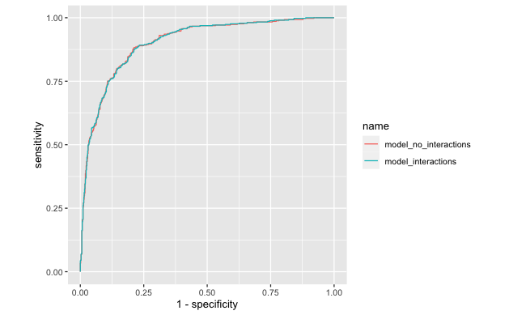

```r
roc_curve <- ggroc(data = list(model_no_interactions = roc_obj_no_interactions, model_interactions = roc_obj_interactions), legacy.axes = TRUE) +
  coord_fixed()

roc_curve
```

The ROC curves are almost equal and both are really good classifiers for the training data. Let’s calculate AUCs.

```r
auc(roc_obj_no_interactions, )
```

```
Area under the curve: 0.902
```

```r
auc(roc_obj_interactions, )
```

```
Area under the curve: 0.9022
```

The model with interactions has a slightly bigger area under the curve. But the difference is almost 0. Both models show almost excellent ROC curves and AUCs. Thus both are almost excellent classifiers for the training data. Let’s see how they perform on test data via cross validation.

```r
train_control <- trainControl(method = "repeatedcv",
                              number = 5,
                              repeats = 100,
                              savePredictions = TRUE,
                              classProbs = TRUE,
                              summaryFunction = twoClassSummary)
```

```r
juice_cross <- juice %>%
  mutate(purchase_mm = as.factor(if_else(purchase_mm, "t", "f")))
```

```r
model_cross_no_interactions <- train(purchase_mm ~ price_ch + price_mm + disc_mm + loyal_ch + pct_disc_mm + pct_disc_ch,
               data = juice_cross,
               trControl = train_control,
               method = "glm",
               family = binomial(link = 'logit'))
```

```
The metric "Accuracy" was not in the result set. ROC will be used instead.
```

```r
summary(model_cross_no_interactions)
```

```
Call:
NULL

Deviance Residuals:
    Min       1Q   Median       3Q      Max
-2.7687  -0.5643  -0.2377   0.5370   2.8215

Coefficients:
            Estimate Std. Error z value Pr(>|z|)
(Intercept)   4.8659     1.7580   2.768  0.00564 **
price_ch      3.5508     1.1432   3.106  0.00190 **
price_mm     -4.1735     0.8422  -4.956 7.21e-07 ***
disc_mm      27.3217     8.5796   3.185  0.00145 **
loyal_ch     -6.4412     0.3929 -16.395  < 2e-16 ***
pct_disc_mm -52.1513    17.9007  -2.913  0.00358 **
pct_disc_ch  -8.1987     1.6841  -4.868 1.13e-06 ***
---
Signif. codes:  0 ‘***’ 0.001 ‘**’ 0.01 ‘*’ 0.05 ‘.’ 0.1 ‘ ’ 1

(Dispersion parameter for binomial family taken to be 1)

    Null deviance: 1430.85  on 1069  degrees of freedom
Residual deviance:  826.96  on 1063  degrees of freedom
AIC: 840.96

Number of Fisher Scoring iterations: 5
```

```r
model_cross_no_interactions$results
```

|  | parameter | ROC | Sens | Spec | ROCSD | SensSD | SpecSD |
| --- | --- | --- | --- | --- | --- | --- | --- |
| 1 | none | 0.899155 | 0.8814248 | 0.7463328 | 0.01970039 | 0.02776277 | 0.04629343 |

```r
model_cross_interactions <- train(purchase_mm ~ price_ch + price_mm + loyal_ch + pct_disc_mm + pct_disc_ch + pct_disc_mm:price_mm + pct_disc_ch:loyal_ch,
               data = juice_cross,
               trControl = train_control,
               method = "glm",
               family = binomial(link = 'logit'))
```

```
The metric "Accuracy" was not in the result set. ROC will be used instead.
```

```r
summary(model_cross_interactions)
```

[output not shown]

```r
model_cross_interactions$results
```

|  | parameter | ROC | Sens | Spec | ROCSD | SensSD | SpecSD |
| --- | --- | --- | --- | --- | --- | --- | --- |
| 1 | none | 0.8988892 | 0.8784775 | 0.7475648 | 0.01799504 | 0.0282749 | 0.04159661 |

Both models have AUCs of just under 0.90 for the test data. They are almost excellent classifiers for the test data. The similar values of AUC for test data (0.89) and for training data (0.90) show there is not over-fitting.